# Felipe Duarte Portfólio

## Dado Pessoais

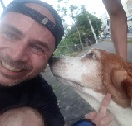

- Nome: Felipe Duarte
- Cidade: Blumenau/SC
- [Instituto Federal Catarinense](https://ifc.edu.br/)
- Função: Pesquisador Institucional
- Cargo: Técnico em Tecnologia da Informação
- felipe.duarte@ifc.edu.br
- [Currículo Lattes](http://lattes.cnpq.br/3493938289222172)
- [GitHub](https://github.com/fduarte79)
- Interesses:
  - Ciência de Dados
  - Python
  - R
  - Bash
  - C
  - matematica
  - estatística
  - GNU/Linux
  - segurança da informação.

## Certificados de Cursos

#### Pós-graduação

- Segurança da Informação - [Pós-Graduação latu sensu/EAD Senac Santo Amaro](https://www1.sp.senac.br/sites/posgraduacao/#cursos_oferecidos)

#### Graduação

- Tecnologia em Redes de Computadores - [UFSM](https://www.ufsm.br/cursos/graduacao/santa-maria/tecnologia-em-redes-de-computadores/)

#### Cursos de Línguas (*em curso*)

- [Get It Blumenau](https://www.linkedin.com/company/get-it-blumenau)

#### Cursos de Programação (*em curso*)

- [Didática Tech](https://didatica.tech/curso-redes-neurais-deep-learning-e-visao-computacional/)

## Estudos de casos

- [Despesas com viagens, diárias e outros gastos com dados obtidos do portal da transparência](https://github.com/fduarte79/viagens2021).
- [siconfi](https://fduarte79.github.io/siconfi/) (Estudo de caso para a Base dos Dados)

## R

#### Estatísticas básica, equações, cálculos

#### Dataframes úteis, propriedades

#### Funções e bilbiotecas úteis para exploração de df

- [Explorando o df](https://fduarte79.github.io/r/src/aed/ggplot_geom_df.html),
- Conceitos e funções básicas: [parte 1](https://fduarte79.github.io/r/src/aed/est_aed_part1.html), explorando com gráficos [parte 2](https://fduarte79.github.io/r/src/aed/est_aed_part2.html)

#### Gráficos

- `ggplot`: [dispersão](https://fduarte79.github.io/r/src/aed/ggplot_geom_point.html), [disperssão (smooth)](https://fduarte79.github.io/r/src/aed/ggplot_geom_smooth.html), [barras e polar](https://fduarte79.github.io/r/src/aed/ggplot_geom_bar.html), [boxplot](https://fduarte79.github.io/r/src/aed/ggplot_geom_boxplot.html)

### Matemática e Estatística

### Resumos

- [Comandos usado no Git](https://github.com/fduarte79/git/blob/main/README.md)

## Sugestões de Estudo em Ciência de Dados e Aprendizagem de Máquina

- **Fundamentos de Estatística para Ciência de Dados**: Fundamentos da linguagem R e sua interface com Python. Elementos de estatística descritiva, inferencial e preditiva. As abordagens clássica, bayesiana e de modelagem algorítmica. Previsão de séries temporais.
- **Introdução à Ciência de Dados e à Inteligência Artificial**: Fundamentos de Ciência de Dados: um pouco de história; as disciplinas; data x big data. Estado da arte: academia e indústria. Estudo de conceitos relacionados à Ciência de Dados: mentalidade orientada a dados, inferência estatística, análise de dados exploratória, o processo da ciência de dados, os processos de negócios x ciência de dados. Visão geral sobre algoritmos: regressão, similaridade, vizinhos, agrupamentos. Pensamento analítico: o que são bons modelos, visualização. Aplicações. Fundamentos de Inteligência Artificial: um pouco de história; as disciplinas; a noção de inteligência. Visão Geral das Áreas da IA: Representação do Conhecimento, Raciocínio e Planejamento; Agentes e Sistemas Multiagentes; Robótica; Machine Learning. Conceitos de Processamento da Língua Natural. Conceitos de Visão Computacional.
- **Introdução ao Python**: Estruturas de Dados no Python, Comandos Básicos, Pacotes e Bibliotecas Essenciais, Numpy, Matplotlib, Seaborn, Pandas, Statmodel, Scikit-learn.
- **Introdução Estatística**: Elementos de Inferência, Clássica e Bayesiana; Métodos de Estimação: Pontual e Intervalar, Teste de Hipótese, Métodos Computacionais Intensivos e Aproximações.
- **Python para Ciência de Dados**: Introdução a vetores e suas operações com Numpy. Uso de matrizes e suas operações: medidas populacionais, amostragem. Utilização de Pandas aplicando dataframes e suas operações: séries e suas operações, medidas populacionais e entrada e saída. Utilização de Matplotlib para visualização, através de gráficos de dispersão, gráficos de linhas, projeções populacionais e outros tipos de visualização. Introdução ao Scikit-Learn, explorando características básicas de modelos de aprendizado (classificação, regressão e agrupamento) e medidas de avaliação.
- **Gerência de Infraestrutura para Big Data**: Introdução à arquitetura para Big Data Analytics. Visão geral sobre Infraestrutura de armazenamento de dados para Big Data. Visão geral sobre Infraestrutura de computação e de rede para Big Data. Tópicos sobre virtualização e computação em nuvem. Plataformas de Big Data na nuvem: HDFS, Hadoop e MapReduce. Estudos de caso com Spark.
- **Visualização de Dados**: Introdução à área de visualização de dados e suas aplicações. Visualização de informações e visual analytics. Percepção, tipos de dados, representações visuais e princípios de interação. Estratégias para comunicação de resultados através de visualização.
- **Inteligência de Negócio**: Visão geral sobre sistemas de suporte à decisão e inteligência de negócio. Estudo sobre armazéns de dados e sobre modelagem OLAP. Compreensão dos principais conceitos envolvidos e entendimento sobre os principais modelos OLAP.
- **Pré-processamento de Dados**: Visão geral sobre obtenção e transformação de dados. Compreensão e prática de técnicas de transformação de dados estruturados e não-estruturados (pré-processamento). Foco em normalização de dados para tarefas de análise e aprendizado de máquina.
- **Aprendizado Supervisionado II**: Estruturas de Dados no Python, Comandos Básicos, Pacotes e Bibliotecas Essenciais, Numpy, Matplotlib, Seaborn, Pandas, Statmodel, Scikit-learn.
- **Redes Neurais e Deep Learning**: Estruturas de Dados no Python, Comandos Básicos, Pacotes e Bibliotecas Essenciais, Numpy, Matplotlib, Seaborn, Pandas, Statmodel, Scikit-learn.
- **Bancos de Dados Relacionais e Não-Relacionais**: Estudo sobre dados espaço-temporais, multimídia, hipermídia, de fluxo contínuo e de mídias digitais. Visão geral sobre a gestão de bancos de dados sem esquemas prévios. Visão geral sobre novas aplicações em dados: Big data, Dados não estruturados, de mídias sociais.
- **Banco de Dados**: Estruturas de Dados no Python, Comandos Básicos, Pacotes e Bibliotecas Essenciais, Numpy, Matplotlib, Seaborn, Pandas, Statmodel, Scikit-learn.
- **Machine Learning I**: Aprendizado Supervisionado: Introdução ao aprendizado supervisionado. Apresentação dos paradigmas de aprendizado: aprendizado baseado em distância (K-NN), aprendizado baseado em procura (árvores de decisão para classificação e regressão), aprendizado probabilístico (Naïve Bayes e Redes Bayesianas), aprendizado baseado em otimização (Regressão Linear e Logística, Redes Neurais Artificiais, Máquinas de Vetores de Suporte), aprendizado em comitês (Random Forests, Bagging, Boosting). Avaliação de modelos preditivos.
- **Machine Learning II**: Aprendizado Não Supervisionado: Introdução ao aprendizado não-supervisionado. Apresentação dos paradigmas de agrupamento de dados, tanto particional com e sem sobreposição como hierárquico e baseado em densidade. Aplicação de redução de dimensionalidade, abordando a maldição da dimensionalidade e os métodos de redução de dimensionalidade. Introdução aos modelos geradores e avaliação de aprendizado não-supervisionado.
- **Deep Learning I**: Redes Neurais para Visão Computacional: Introdução à Visão Computacional com Deep Learning. Redes Neurais Convolucionais: arquiteturas; camadas convolucionais; camadas totalmente conectadas; camadas de pooling; conexões residuais; regularização via weight decay; regularização via dropout; funções de ativação; funções de custo. Classificação de Imagens. Localização de Objetos. Detecção de Objetos. Segmentação Semântica. Segmentação de Instâncias. Redes Geradoras Adversárias.
- **Deep Learning II**: Redes Neurais para Processamento de Linguagem Natural: Introdução à Processamento de Linguagem Natural com Deep Learning. Representações vetoriais de palavras (word embeddings). Modelos de Linguagens. Redes Neurais Recorrentes (Vanilla, LSTMs, GRUs). Tradução de Máquina. Arquiteturas sequence-to-sequence. Mecanismos de Atenção. Transformers. Representações contextuais de palavras. Aplicações multimodais: recuperação bidirecional; síntese de imagens baseada em texto; Visual Question Answering (VQA). Framework de deep learning (pytorch).
- **Aprendizado Supervisionado I**: Introdução à modelo linear geral; Regressão múltipla; Regressão na família exponencial; Dados binários e regressão logística; Regressão com penalização L1 e L2; Regressão por splines.
- **Previsões Bayesianas e Modelos Gráficos**: Modelos Em Espaço de Estados, Distribuições a Priori e a Posteriori; Distribuição Preditiva; Seleção de Modelos; Modelos Gráficos Direcionados e Não Direcionados; Inferência e Algoritmos.
- **Aprendizado Não Supervisionado**: K-MEDIAS, Modelos de Mistura, Redes Neurais Não-supervisionadas, Algoritmo EM; Análise de Componentes Principais.
- **Mineração de dados**: Introdução ao Aprendizado de Máquina, Visualização de Dados, Apresentação de Conceitos Básicos, Apresentação de Alguns Problemas Relevantes.
- **Métodos de Otimização**: Exemplos de Problemas de Otimização, Programação Linear e Aplicações, Programação Quadrática a Aplicações, Modelos Mais Gerais, Otimização Diferenciável: Condições de Otimalidade, Métodos de Solução, Análise de Convergência Local e Global, Aplicações, Otimização Robusta, Otimização Estocástica, Controle Ótimo.
- **Introdução a Modelagem de Incertezas**: Conceitos de Probabilidade, Probabilidade Condicional, Modelos para Variáveis Aleatórias Discretas e Continuas, Distribuições Condicionais, Teorema de Bayes, Momentos.

## Referências

#### Organizações e Institutos

- [Open Knoledge Brasil](https://ok.org.br/)
- [Escola de Dados](https://escoladedados.org/)
- [Dados Abertos](https://dados.gov.br/)
- [ITS Rio](https://itsrio.org/pt/home/)

#### Twitter

- [Open Knowledge Brasil](https://twitter.com/okfnbr)
- [Escola de Dados](https://twitter.com/EscolaDeDados)
- [Base dos Dados](https://twitter.com/basedosdados)
- [ITS Rio](https://twitter.com/ITSriodejaneiro)

#### Cursos

- [Mooc Técnico](https://courses.elearning.tecnico.ulisboa.pt/)
- [PUCRS - Ciência de Dados](https://online.pucrs.br/pos/ciencia-de-dados)
- [UFRJ - Especialização em Ciência de Dados](http://www.im.ufrj.br/index.php/pt/ensino/pos-graduacao/pos-graduacao-do-im/cursos-lato-sensu/ciencia-de-dados)
- [Coursera](https://www.coursera.org/courses?query=free)
- [Enap](https://enap.gov.br/pt/)
- [Escola Virtual](https://www.escolavirtual.gov.br/)
- [Kaggle](https://www.kaggle.com/learn)
- [Data Science Academy](https://www.datascienceacademy.com.br/)
- [Estatística com R](https://storopoli.io/Estatistica/)
- [Software R: curso avançado](https://smolski.github.io/livroavancado/)
- [RPubs - EstatBasica](https://rpubs.com/EstatBasica)

#### Acadêmicos - artigos, TCC’s, projetos de pesquisa

#### Reportagens e publicações específicas

- [How to Become Data Scientist – A Complete Roadmap](https://www.geeksforgeeks.org/how-to-become-data-scientist-a-complete-roadmap/)
- [Guia do Cientista de Dados das Galáxias](https://github.com/utzig/data-science-roadmap)
- [Como criar um PLANO DE ESTUDOS para se tornar um CIENTISTA DE DADOS? (Roadmap Ciência de Dados)](https://www.youtube.com/watch?v=o8NpsLSkKUo)
- [10 Cursos de Data Science do Kaggle gratuitos para iniciantes](https://medium.com/data-hackers/10-cursos-de-data-science-do-kaggle-gratuitos-para-iniciantes-b0adb00dfd9e)

#### Canais e Vídeos no Youtube

- [DidaticaTech](https://www.youtube.com/c/Did%C3%A1ticaTech/playlists)
- [Estatística com R](https://www.youtube.com/playlist?list=PLuQWWXrHQLiejECp_ldRPEjuVnJrG7fVS)
- [Fernanda Peres](https://www.youtube.com/c/FernandaPeres/playlists)
- [Programação Dinâmica](https://www.youtube.com/channel/UC70mr11REaCqgKke7DPJoLg)

#### Linguas

- [DW](https://learngerman.dw.com/pt-br/overview)
- [Lud Fonseca Sprache&Wissen](https://www.youtube.com/c/Alem%C3%A3oFluente/featured)
- [Learn English with EnglishClass101.com](https://www.youtube.com/c/EnglishClass101/playlists)
- [Rachel’s English](https://www.youtube.com/c/rachelsenglish/playlists)

#### Discord

- [Open Knowledge Brasil](https://discord.com/invite/aC3Q33q)
- [Base dos Dados](https://discord.com/invite/huKWpsVYx4)

#### Inspiradorações

- [Dennis M. Ritchie](https://www.bell-labs.com/usr/dmr/www/)
- [Eric S. Raymond’s Home Page](http://www.catb.org/esr/)
- [Liane Margarida Rockenbach Tarouco](http://penta3.ufrgs.br/liane/Liane%20Margarida%20Rockenbach%20Tarouco.htm)
- [Raul Fernando Weber](https://www.inf.ufrgs.br/site/docente/raul-fernando-weber/)
- [AT&T Archives: The UNIX Operating System](https://www.youtube.com/watch?v=tc4ROCJYbm0)
- [Programação Dinâmica](https://www.youtube.com/channel/UC70mr11REaCqgKke7DPJoLg)
- [Ken Thompson and Dennis Ritchie Explain UNIX (Bell Labs)](https://www.youtube.com/watch?v=JoVQTPbD6UY)